# MILESTONE

Group 12

### Tên đề tài :

# Students Performance in Exams

[output not shown]

**1. Sự đóng góp của các thành viên**

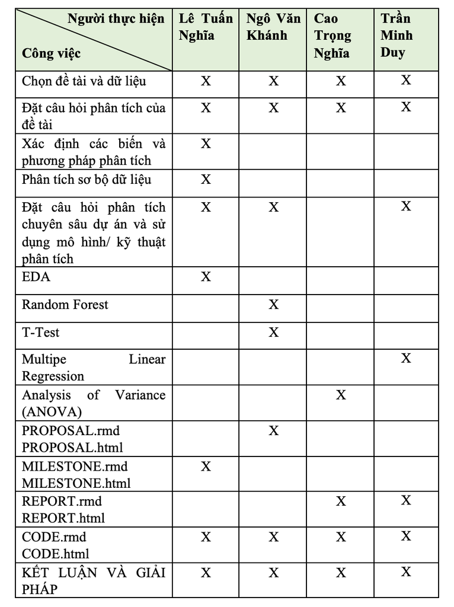

```r
library(knitr)
include_graphics("./image/phan_chia_cong_viec.png")
```

**2. Thông tin về project:** - *Bài toán nhóm muốn giải quyết*: + Mục tiêu nghiên cứu các yếu tố xung quanh có ảnh hướng đến đến thành tích của học sinh - sinh viên hay không? Từ việc thu thập thành tích và các yếu tố liên quan, từ đó đưa ra kết luận và đưa ra giải pháp để nâng cao giáo dục thời nay. + Mức ảnh hưởng của các biến trong dữ liệu với nhau ? + Dự đoán sự biến đổi chênh lệch điểm số thông qua các yếu tố ảnh hưởng ?

```
- *Nguồn dữ liệu*:Dữ liệu này được trích xuất từ website kaggle                                *https://www.kaggle.com/datasets/spscientist/students-  performance-in-exams*
- Dữ liệu trên gồm tập hợp của các bộ dữ liệu được thu thập từ các trường trung học tại Hoa Kì. Với 5 biến, tổng 1000 quan sát để làm yếu tố, giải thích cho thành tích của học sinh - sinh viên và 4 biến (math_score, reading_score, writing_score, total_score)là biến để biểu diễn thành tích cuối cùng …
  +biến quan sát(giải thích)(X): gender
                race.ethnicity
                parental_level_of_education
                lunch
                test_preparation_course

+ biến kết quả(Y): math_score
                reading_score
                writing_score
                total_score *biến được tạo thêm*

- *Mô tả và ý nghĩa*:
    gender: giới tính.
        race/ethnicity: chủng tộc / dân tộc.
        parental_level_of_education: Trình độ học vấn gia đình.
        lunch: Ăn trưa trước khi vào kỳ thi.
        test_preparation_course: Tham gia các khóa luyện thi trước kỳ thi  .
        math_score: điểm toán.
        reading_score: điểm đọc .
        writing_score: điểm viết.
        total_score: điểm trung bình. (Giúp dễ dàng hơn trong việc trực quan hóa dữ liệu) *biến được tạo thêm*
```

*Kỹ thuật phân tích và thuật toán sử dụng mà nhóm tin rằng hữu ích cho việc phân tích và đã sử dụng* - Phân tích EDA - Kiểm định T-test - Random Forest model - Multipe Linear Regression - Analysis of Variance (ANOVA)

*Cách đánh giá kết quả* - Phân tích EDA và trực quan hoá đồ thị để hiểu thêm tập dữ liệu và phục vụ cho công việc phân tích - Câu hỏi đề ra để phân tích dữ liệu - Phân tích sâu vào bộ dữ liệu

**3. Giải pháp và kết quả sơ bộ**

*Phân tích sơ lược tập dữ liệu*

******Thống kê tất cả các biến số có trong tập dữ liệu và đưa ra sự chênh lệch giữa các nhóm với nhau.******

[output not shown]

******Phân tích các yếu tố có ảnh hưởng đến thành tích? Đâu là những yếu tố ảnh hưởng lớn nhất?******

[output not shown]

******Mối quan hệ giữa các biến khác với test_preparation_course trong tập dữ liệu?******

[output not shown]

*Phân tích sâu vào bộ dữ liệu*

******Tìm hiểu xem liệu có mối quan hệ đáng kể nào giữa giới tính, thu nhập của cha mẹ, trình độ học vấn của cha mẹ và điểm kiểm tra hay không?******

[output not shown]

******Mô hình RANDOM FOREST để tìm xem đâu là biến quan trọng nhất gây tác động đến điểm số của học sinh******

[output not shown]

[output not shown]

******Liệu có thể dự đoán được tổng điểm của học sinh qua các biến gender, test_preparation_course, reading_score và writing_score, sử dụng model Multipe Linear Regression******

[output not shown]

******Liệu có mối quan hệ đáng kể nào giữa dân tộc, trình độ học vấn của cha mẹ với điểm kiểm tra hay không?******

[output not shown]